# Communicate_Data_Slide_Deck slides

Ford Gobike Data Exploration

by Peiru Cai

Preliminary Wrangling

Investigation Overview

Bay Wheels (previously known as Ford GoBike) is 'the first regional and large-scale bicycle sharing system deployed in California and on the West Coast of the United States.This document will explore a dataset which contain approximately 183.412 Fordgobike trip data for better analyze people's bike usage habits and behavior characteristics.

Ford Gobike Usage by Weekday

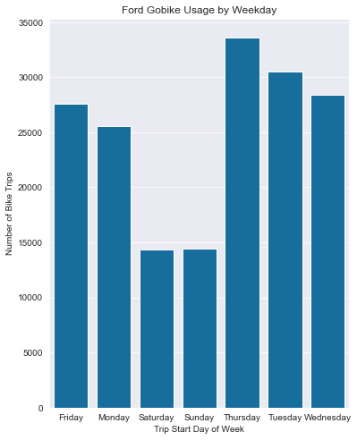

```python
# Weekday usage of the Ford Go bike system
weekday = ['Monday', 'Tuesday', 'Wednesday', 'Thursday', 'Friday', 'Saturday', 'Sunday']
sb.countplot(data=df_clean, x='start_day_of_week', color=base_color);
plt.title('Ford Gobike Usage by Weekday')
plt.xlabel('Trip Start Day of Week');
plt.ylabel('Number of Bike Trips');
```

Based on the distribution of the itinerary on a certain day of the week, it's obvious that most of the itineraries take place on weekdays (Mon-Fri), and the main purpose may be commuting.

Distribution of Ford Gobike Gender

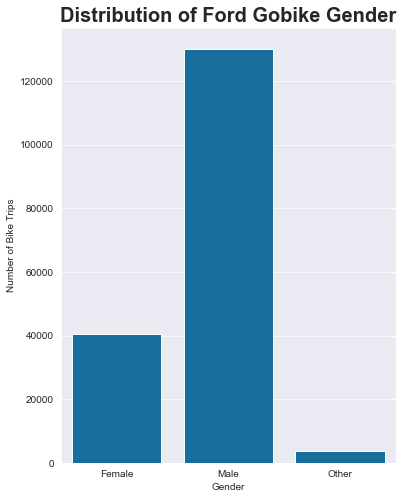

```python
sb.countplot(data=df_clean, x='member_gender', color=base_color);
plt.xlabel('Gender');
plt.ylabel('Number of Bike Trips');
plt.title('Distribution of Ford Gobike Gender',fontsize=20,fontweight='bold')
```

From the data analysis chart above, it can be seen that most riders are male subscribers.

Distribution of Ford Gobike Member Age

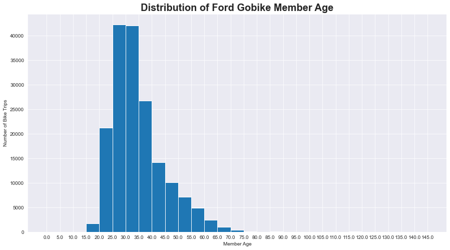

```python
plt.figure(figsize=(15, 8))
bins = np.arange(0, df_clean['member_age'].max()+5, 5)
plt.hist(data=df_clean, x='member_age', bins=bins);
plt.xticks(bins, bins);
plt.xlabel('Member Age');
plt.ylabel('Number of Bike Trips');
plt.title('Distribution of Ford Gobike Member Age',fontsize=20,fontweight='bold')
```

Most of the users age are between 25-40 years old.As age increases, the user of FordGoBike has dropped significantly.

Ford Gobike System Trip Duration in minutes

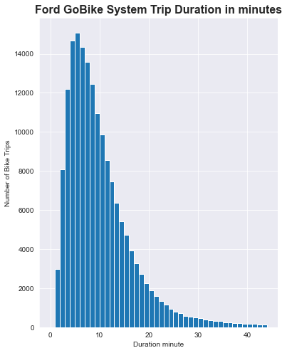

```python
bin_edges = np.arange(0, 45, 1)
plt.hist(data = df_clean, x = 'duration_minute', bins = bin_edges);
plt.title("Ford GoBike System Trip Duration in minutes", y=1, fontsize=16, fontweight='bold')
plt.xlabel('Duration minute')
plt.ylabel('Number of Bike Trips');
```

Based on the above histgram, we found that most riders are in the range of 3-12 mins, which indicates that they are riding short distances.

Bivariate Exploration

Average minute of duration between customers and subscribers

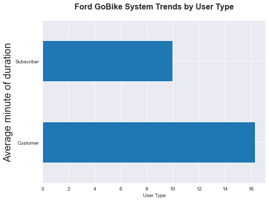

```python
# What is the difference in travel time distribution between customers and subscribers?
plt = df_clean.groupby('user_type')['duration_minute'].mean().plot(kind='barh', figsize=(8,6));

plt.set_title('Ford GoBike System Trends by User Type', y=1.05, fontsize=16, fontweight='bold')
plt.set_xlabel('User Type')
plt.set_ylabel('Average minute of duration',fontsize=20)
```

Bike usage during the day between customer and subscriber

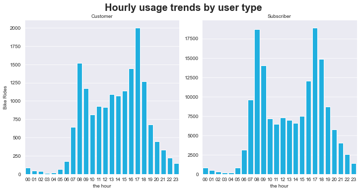

```python
g = sb.catplot(data=df_clean, x='start_hour_of_day', col="user_type", kind='count', sharey = False,
            color = 'deepskyblue')
g.set_axis_labels("the hour", "Bike Rides")
g.set_titles("{col_name}")
g.fig.suptitle('Hourly usage trends by user type', y=1.03,fontsize=20, fontweight='bold');
```

The number of sharing bikes used by subscribers far exceeds the number of sharing bikes used by customers during the day. Furthermore, 7 am-9 am vs 16 pm-18 pm are the times when the number of bicycles is the most in a day. In addition, the peak period is at 8 in the morning and 5 in the afternoon separately.

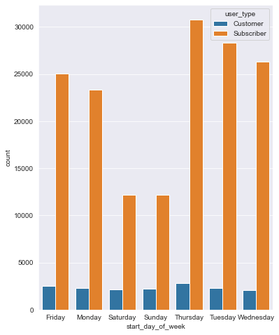

```python
sb.countplot(data=df_clean, x='start_day_of_week', hue='user_type');
plt.set_xlabel('Day of Week');
plt.set_ylabel('Count');
plt.set_title('Usage of Different User Types by Weekly',fontsize=16, fontweight='bold')
```

The number of sharing bike used by subscribers far exceeds the number of sharing bike used by customers during the week.